# HW8_B87772

The formula of dynamic time warping algorithm is: For the values on left in matrice: │Ai - Bj │+ D [i-1,0]

For the elements on bottom of matrice: │Ai - Bj │+ D [0, j-1]

For the remaining elements: │Ai - Bj │+ min (D [i-1, j-1] D [i-1, j] D [i, j-1])

My pairs areS2 and S4, S1 and S5, S3 and S6.

Below I provided the visualization and calculated pairwise distances.

| 8 | 66 | 29 | 21 | 25 | 17 | 22 | 15 | 14 | 15 | 22 | 22 | 19 | 10 | 9 |
| --- | --- | --- | --- | --- | --- | --- | --- | --- | --- | --- | --- | --- | --- | --- |
| 7 | 59 | 26 | 20 | 22 | 16 | 19 | 13 | 14 | 16 | 19 | 16 | 14 | 9 | 10 |
| 6 | 53 | 24 | 20 | 18 | 16 | 14 | 12 | 15 | 17 | 14 | 11 | 10 | 9 | 11 |
| 2 | 48 | 23 | 19 | 15 | 15 | 10 | 16 | 14 | 14 | 7 | 7 | 8 | 13 | 19 |
| 9 | 47 | 20 | 14 | 18 | 10 | 15 | 10 | 7 | 7 | 14 | 21 | 26 | 23 | 20 |
| 9 | 39 | 16 | 12 | 16 | 8 | 13 | 9 | 7 | 7 | 14 | 20 | 16 | 21 | 19 |
| 9 | 31 | 12 | 10 | 12 | 6 | 11 | 8 | 7 | 7 | 14 | 21 | 24 | 19 | 18 |
| 6 | 23 | 8 | 8 | 6 | 4 | 8 | 7 | 10 | 13 | 17 | 19 | 18 | 17 | 19 |
| 2 | 17 | 7 | 7 | 3 | 8 | 5 | 11 | 18 | 20 | 15 | 15 | 16 | 21 | 27 |
| 7 | 16 | 4 | 2 | 6 | 5 | 10 | 11 | 13 | 15 | 20 | 25 | 29 | 29 | 30 |
| 6 | 10 | 2 | 2 | 5 | 6 | 10 | 12 | 15 | 18 | 22 | 26 | 29 | 30 | 32 |
| 5 | 5 | 1 | 3 | 5 | 7 | 10 | 13 | 17 | 21 | 24 | 27 | 29 | 31 | 34 |
| 2 | 1 | 3 | 8 | 9 | 14 | 14 | 20 | 27 | 34 | 34 | 34 | 35 | 40 | 46 |
| 1 | 0 | 4 | 10 | 12 | 18 | 19 | 26 | 34 | 42 | 43 | 44 | 46 | 52 |  |
|  | 1 | 5 | 7 | 3 | 7 | 2 | 8 | 9 | 9 | 2 | 2 | 3 | 7 | 8 |

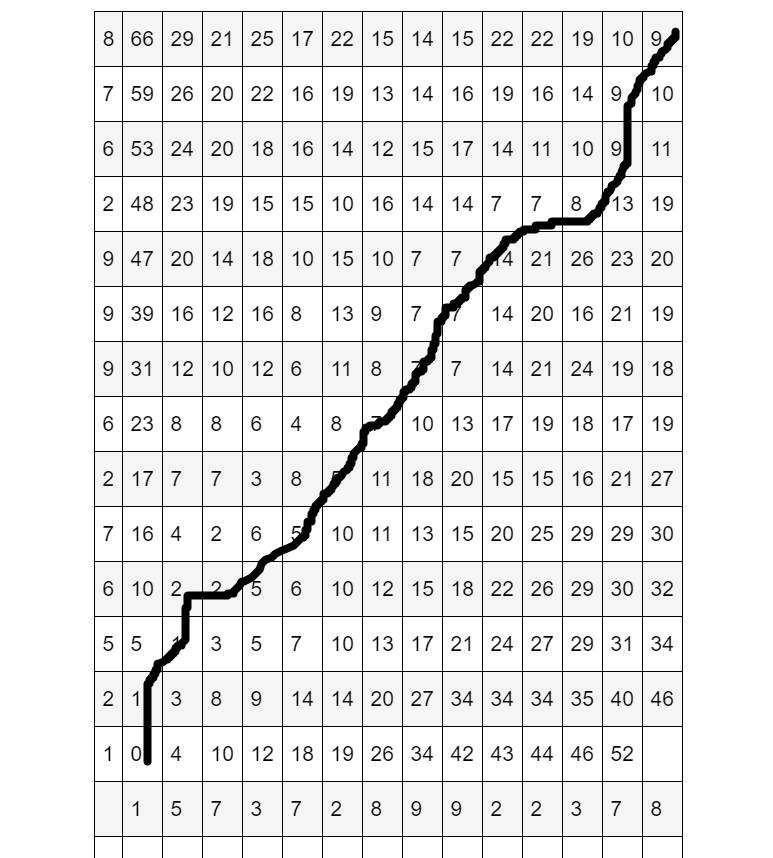

```python
from IPython.display import HTML, display
from IPython.display import Image

display(HTML(
    '<style type="text/css">.tg {border-collapse:collapse;border-spacing:0;}.tg td{font-family:Arial, sans-serif;font-size:14px;padding:10px 5px;border-style:solid;border-width:1px;overflow:hidden;word-break:normal;border-color:black;}.tg th{font-family:Arial, sans-serif;font-size:14px;font-weight:normal;padding:10px 5px;border-style:solid;border-width:1px;overflow:hidden;word-break:normal;border-color:black;}.tg .tg-dvpl{border-color:inherit;text-align:right;vertical-align:top}.tg .tg-0pky{border-color:inherit;text-align:left;vertical-align:top}</style><table class="tg"> <tr> <th class="tg-dvpl">8</th> <th class="tg-0pky">66</th> <th class="tg-0pky">29</th> <th class="tg-0pky">21</th> <th class="tg-0pky">25</th> <th class="tg-0pky">17</th> <th class="tg-0pky">22</th> <th class="tg-0pky">15</th> <th class="tg-0pky">14</th> <th class="tg-0pky">15</th> <th class="tg-0pky">22</th> <th class="tg-0pky">22</th> <th class="tg-0pky">19</th> <th class="tg-0pky">10</th> <th class="tg-0pky">9</th> </tr> <tr> <td class="tg-0pky">7</td> <td class="tg-0pky">59</td> <td class="tg-0pky">26</td> <td class="tg-0pky">20</td> <td class="tg-0pky">22</td> <td class="tg-0pky">16</td> <td class="tg-0pky">19</td> <td class="tg-0pky">13</td> <td class="tg-0pky">14</td> <td class="tg-0pky">16</td> <td class="tg-0pky">19</td> <td class="tg-0pky">16</td> <td class="tg-0pky">14</td> <td class="tg-0pky">9</td> <td class="tg-0pky">10</td> </tr> <tr> <td class="tg-0pky">6</td> <td class="tg-0pky">53</td> <td class="tg-0pky">24</td> <td class="tg-0pky">20</td> <td class="tg-0pky">18</td> <td class="tg-0pky">16</td> <td class="tg-0pky">14</td> <td class="tg-0pky">12</td> <td class="tg-0pky">15</td> <td class="tg-0pky">17</td> <td class="tg-0pky">14</td> <td class="tg-0pky">11</td> <td class="tg-0pky">10</td> <td class="tg-0pky">9</td> <td class="tg-0pky">11</td> </tr> <tr> <td class="tg-0pky">2</td> <td class="tg-0pky">48</td> <td class="tg-0pky">23</td> <td class="tg-0pky">19</td> <td class="tg-0pky">15</td> <td class="tg-0pky">15</td> <td class="tg-0pky">10</td> <td class="tg-0pky">16</td> <td class="tg-0pky">14</td> <td class="tg-0pky">14</td> <td class="tg-0pky">7</td> <td class="tg-0pky">7</td> <td class="tg-0pky">8</td> <td class="tg-0pky">13</td> <td class="tg-0pky">19</td> </tr> <tr> <td class="tg-0pky">9</td> <td class="tg-0pky">47</td> <td class="tg-0pky">20</td> <td class="tg-0pky">14</td> <td class="tg-0pky">18</td> <td class="tg-0pky">10</td> <td class="tg-0pky">15</td> <td class="tg-0pky">10</td> <td class="tg-0pky">7</td> <td class="tg-0pky">7</td> <td class="tg-0pky">14</td> <td class="tg-0pky">21</td> <td class="tg-0pky">26</td> <td class="tg-0pky">23</td> <td class="tg-0pky">20</td> </tr> <tr> <td class="tg-0pky">9</td> <td class="tg-0pky">39</td> <td class="tg-0pky">16</td> <td class="tg-0pky">12</td> <td class="tg-0pky">16</td> <td class="tg-0pky">8</td> <td class="tg-0pky">13</td> <td class="tg-0pky">9</td> <td class="tg-0pky">7</td> <td class="tg-0pky">7</td> <td class="tg-0pky">14</td> <td class="tg-0pky">20</td> <td class="tg-0pky">16</td> <td class="tg-0pky">21</td> <td class="tg-0pky">19</td> </tr> <tr> <td class="tg-0pky">9</td> <td class="tg-0pky">31</td> <td class="tg-0pky">12</td> <td class="tg-0pky">10</td> <td class="tg-0pky">12</td> <td class="tg-0pky">6</td> <td class="tg-0pky">11</td> <td class="tg-0pky">8</td> <td class="tg-0pky">7</td> <td class="tg-0pky">7</td> <td class="tg-0pky">14</td> <td class="tg-0pky">21</td> <td class="tg-0pky">24</td> <td class="tg-0pky">19</td> <td class="tg-0pky">18</td> </tr> <tr> <td class="tg-0pky">6</td> <td class="tg-0pky">23</td> <td class="tg-0pky">8</td> <td class="tg-0pky">8</td> <td class="tg-0pky">6</td> <td class="tg-0pky">4</td> <td class="tg-0pky">8</td> <td class="tg-0pky">7</td> <td class="tg-0pky">10</td> <td class="tg-0pky">13</td> <td class="tg-0pky">17</td> <td class="tg-0pky">19</td> <td class="tg-0pky">18</td> <td class="tg-0pky">17</td> <td class="tg-0pky">19</td> </tr> <tr> <td class="tg-0pky">2</td> <td class="tg-0pky">17</td> <td class="tg-0pky">7</td> <td class="tg-0pky">7</td> <td class="tg-0pky">3</td> <td class="tg-0pky">8</td> <td class="tg-0pky">5</td> <td class="tg-0pky">11</td> <td class="tg-0pky">18</td> <td class="tg-0pky">20</td> <td class="tg-0pky">15</td> <td class="tg-0pky">15</td> <td class="tg-0pky">16</td> <td class="tg-0pky">21</td> <td class="tg-0pky">27</td> </tr> <tr> <td class="tg-0pky">7</td> <td class="tg-0pky">16</td> <td class="tg-0pky">4</td> <td class="tg-0pky">2</td> <td class="tg-0pky">6</td> <td class="tg-0pky">5</td> <td class="tg-0pky">10</td> <td class="tg-0pky">11</td> <td class="tg-0pky">13</td> <td class="tg-0pky">15</td> <td class="tg-0pky">20</td> <td class="tg-0pky">25</td> <td class="tg-0pky">29</td> <td class="tg-0pky">29</td> <td class="tg-0pky">30</td> </tr> <tr> <td class="tg-0pky">6</td> <td class="tg-0pky">10</td> <td class="tg-0pky">2</td> <td class="tg-0pky">2</td> <td class="tg-0pky">5</td> <td class="tg-0pky">6</td> <td class="tg-0pky">10</td> <td class="tg-0pky">12</td> <td class="tg-0pky">15</td> <td class="tg-0pky">18</td> <td class="tg-0pky">22</td> <td class="tg-0pky">26</td> <td class="tg-0pky">29</td> <td class="tg-0pky">30</td> <td class="tg-0pky">32</td> </tr> <tr> <td class="tg-0pky">5</td> <td class="tg-0pky">5</td> <td class="tg-0pky">1</td> <td class="tg-0pky">3</td> <td class="tg-0pky">5</td> <td class="tg-0pky">7</td> <td class="tg-0pky">10</td> <td class="tg-0pky">13</td> <td class="tg-0pky">17</td> <td class="tg-0pky">21</td> <td class="tg-0pky">24</td> <td class="tg-0pky">27</td> <td class="tg-0pky">29</td> <td class="tg-0pky">31</td> <td class="tg-0pky">34</td> </tr> <tr> <td class="tg-0pky">2</td> <td class="tg-0pky">1</td> <td class="tg-0pky">3</td> <td class="tg-0pky">8</td> <td class="tg-0pky">9</td> <td class="tg-0pky">14</td> <td class="tg-0pky">14</td> <td class="tg-0pky">20</td> <td class="tg-0pky">27</td> <td class="tg-0pky">34</td> <td class="tg-0pky">34</td> <td class="tg-0pky">34</td> <td class="tg-0pky">35</td> <td class="tg-0pky">40</td> <td class="tg-0pky">46</td> </tr> <tr> <td class="tg-0pky">1</td> <td class="tg-0pky">0</td> <td class="tg-0pky">4</td> <td class="tg-0pky">10</td> <td class="tg-0pky">12</td> <td class="tg-0pky">18</td> <td class="tg-0pky">19</td> <td class="tg-0pky">26</td> <td class="tg-0pky">34</td> <td class="tg-0pky">42</td> <td class="tg-0pky">43</td> <td class="tg-0pky">44</td> <td class="tg-0pky">46</td> <td class="tg-0pky">52</td> <td class="tg-0pky"></td> </tr> <tr> <td class="tg-0pky"></td> <td class="tg-0pky">1</td> <td class="tg-0pky">5</td> <td class="tg-0pky">7</td> <td class="tg-0pky">3</td> <td class="tg-0pky">7</td> <td class="tg-0pky">2</td> <td class="tg-0pky">8</td> <td class="tg-0pky">9</td> <td class="tg-0pky">9</td> <td class="tg-0pky">2</td> <td class="tg-0pky">2</td> <td class="tg-0pky">3</td> <td class="tg-0pky">7</td> <td class="tg-0pky">8</td> </tr> <tr> <td class="tg-0pky"></td> <td class="tg-0pky"></td> <td class="tg-0pky"></td> <td class="tg-0pky"></td> <td class="tg-0pky"></td> <td class="tg-0pky"></td> <td class="tg-0pky"></td> <td class="tg-0pky"></td> <td class="tg-0pky"></td> <td class="tg-0pky"></td> <td class="tg-0pky"></td> <td class="tg-0pky"></td> <td class="tg-0pky"></td> <td class="tg-0pky"></td> <td class="tg-0pky"></td> </tr></table>')
 )
Image("ex1_1.png")
```

| 9 | 53 | 54 | 55 | 57 | 58 | 52 | 36 | 42 | 29 | 28 | 33 | 20 | 25 |
| --- | --- | --- | --- | --- | --- | --- | --- | --- | --- | --- | --- | --- | --- |
| 8 | 47 | 48 | 49 | 50 | 51 | 33 | 35 | 36 | 26 | 25 | 33 | 17 | 23 |
| 6 | 42 | 43 | 43 | 44 | 46 | 33 | 30 | 31 | 24 | 27 | 25 | 15 | 20 |
| 6 | 39 | 39 | 39 | 41 | 41 | 41 | 27 | 28 | 24 | 26 | 20 | 15 | 20 |
| 1 | 36 | 35 | 36 | 36 | 36 | 29 | 24 | 25 | 24 | 23 | 15 | 21 | 17 |
| 9 | 34 | 35 | 36 | 38 | 39 | 22 | 27 | 31 | 19 | 15 | 23 | 17 | 22 |
| 8 | 28 | 29 | 30 | 31 | 33 | 21 | 24 | 25 | 16 | 15 | 23 | 14 | 19 |
| 6 | 23 | 24 | 24 | 25 | 28 | 21 | 19 | 20 | 14 | 17 | 23 | 12 | 17 |
| 6 | 20 | 20 | 20 | 23 | 23 | 19 | 16 | 17 | 14 | 17 | 17 | 12 | 17 |
| 1 | 17 | 16 | 17 | 17 | 17 | 18 | 13 | 14 | 19 | 20 | 12 | 17 | 17 |
| 9 | 15 | 16 | 17 | 19 | 21 | 11 | 16 | 19 | 15 | 12 | 20 | 23 | 28 |
| 7 | 9 | 10 | 11 | 13 | 14 | 10 | 12 | 13 | 12 | 14 | 20 | 20 | 26 |
| 5 | 5 | 6 | 7 | 8 | 9 | 9 | 8 | 11 | 12 | 15 | 19 | 20 | 24 |
| 5 | 3 | 4 | 4 | 5 | 6 | 6 | 11 | 12 | 11 | 15 | 19 | 20 | 24 |
| 2 | 1 | 1 | 1 | 2 | 3 | 9 | 10 | 10 | 14 | 21 | 22 | 26 | 27 |
|  | 3 | 2 | 2 | 1 | 1 | 8 | 3 | 2 | 6 | 9 | 1 | 6 | 1 |

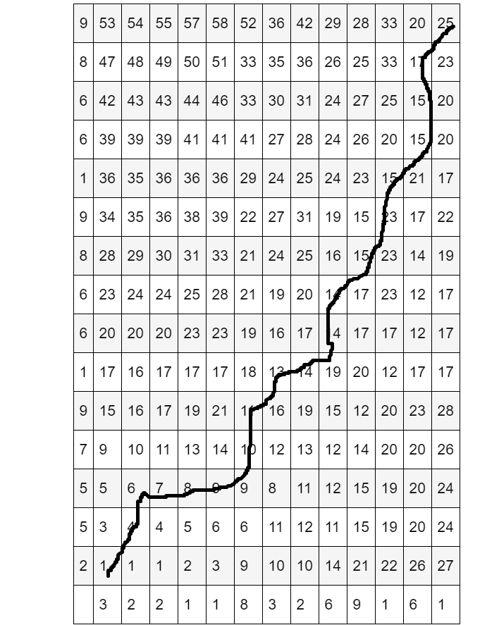

```python
display(HTML(
    '<style type="text/css">.tg {border-collapse:collapse;border-spacing:0;}.tg td{font-family:Arial, sans-serif;font-size:14px;padding:10px 5px;border-style:solid;border-width:1px;overflow:hidden;word-break:normal;border-color:black;}.tg th{font-family:Arial, sans-serif;font-size:14px;font-weight:normal;padding:10px 5px;border-style:solid;border-width:1px;overflow:hidden;word-break:normal;border-color:black;}.tg .tg-dvpl{border-color:inherit;text-align:right;vertical-align:top}.tg .tg-0pky{border-color:inherit;text-align:left;vertical-align:top}.tg .tg-0lax{text-align:left;vertical-align:top}</style><table class="tg"> <tr> <th class="tg-dvpl">9</th> <th class="tg-0pky">53</th> <th class="tg-0pky">54</th> <th class="tg-0pky">55</th> <th class="tg-0pky">57</th> <th class="tg-0pky">58</th> <th class="tg-0pky">52</th> <th class="tg-0pky">36</th> <th class="tg-0pky">42</th> <th class="tg-0pky">29</th> <th class="tg-0pky">28</th> <th class="tg-0pky">33</th> <th class="tg-0pky">20</th> <th class="tg-0pky">25</th> </tr> <tr> <td class="tg-0pky">8</td> <td class="tg-0pky">47</td> <td class="tg-0pky">48</td> <td class="tg-0pky">49</td> <td class="tg-0pky">50</td> <td class="tg-0pky">51</td> <td class="tg-0pky">33</td> <td class="tg-0pky">35</td> <td class="tg-0pky">36</td> <td class="tg-0pky">26</td> <td class="tg-0pky">25</td> <td class="tg-0pky">33</td> <td class="tg-0pky">17</td> <td class="tg-0pky">23</td> </tr> <tr> <td class="tg-0pky">6</td> <td class="tg-0pky">42</td> <td class="tg-0pky">43</td> <td class="tg-0pky">43</td> <td class="tg-0pky">44</td> <td class="tg-0pky">46</td> <td class="tg-0pky">33</td> <td class="tg-0pky">30</td> <td class="tg-0pky">31</td> <td class="tg-0pky">24</td> <td class="tg-0pky">27</td> <td class="tg-0pky">25</td> <td class="tg-0pky">15</td> <td class="tg-0pky">20</td> </tr> <tr> <td class="tg-0pky">6</td> <td class="tg-0pky">39</td> <td class="tg-0pky">39</td> <td class="tg-0pky">39</td> <td class="tg-0pky">41</td> <td class="tg-0pky">41</td> <td class="tg-0pky">41</td> <td class="tg-0pky">27</td> <td class="tg-0pky">28</td> <td class="tg-0pky">24</td> <td class="tg-0pky">26</td> <td class="tg-0pky">20</td> <td class="tg-0pky">15</td> <td class="tg-0pky">20</td> </tr> <tr> <td class="tg-0pky">1</td> <td class="tg-0pky">36</td> <td class="tg-0pky">35</td> <td class="tg-0pky">36</td> <td class="tg-0pky">36</td> <td class="tg-0pky">36</td> <td class="tg-0pky">29</td> <td class="tg-0pky">24</td> <td class="tg-0pky">25</td> <td class="tg-0pky">24</td> <td class="tg-0pky">23</td> <td class="tg-0pky">15</td> <td class="tg-0pky">21</td> <td class="tg-0pky">17</td> </tr> <tr> <td class="tg-0pky">9</td> <td class="tg-0pky">34</td> <td class="tg-0pky">35</td> <td class="tg-0pky">36</td> <td class="tg-0pky">38</td> <td class="tg-0pky">39</td> <td class="tg-0pky">22</td> <td class="tg-0pky">27</td> <td class="tg-0pky">31</td> <td class="tg-0pky">19</td> <td class="tg-0pky">15</td> <td class="tg-0pky">23</td> <td class="tg-0pky">17</td> <td class="tg-0pky">22</td> </tr> <tr> <td class="tg-0pky">8</td> <td class="tg-0pky">28</td> <td class="tg-0pky">29</td> <td class="tg-0pky">30</td> <td class="tg-0pky">31</td> <td class="tg-0pky">33</td> <td class="tg-0pky">21</td> <td class="tg-0pky">24</td> <td class="tg-0pky">25</td> <td class="tg-0pky">16</td> <td class="tg-0pky">15</td> <td class="tg-0pky">23</td> <td class="tg-0pky">14</td> <td class="tg-0pky">19</td> </tr> <tr> <td class="tg-0pky">6</td> <td class="tg-0pky">23</td> <td class="tg-0pky">24</td> <td class="tg-0pky">24</td> <td class="tg-0pky">25</td> <td class="tg-0pky">28</td> <td class="tg-0pky">21</td> <td class="tg-0pky">19</td> <td class="tg-0pky">20</td> <td class="tg-0pky">14</td> <td class="tg-0pky">17</td> <td class="tg-0pky">23</td> <td class="tg-0pky">12</td> <td class="tg-0pky">17</td> </tr> <tr> <td class="tg-0pky">6</td> <td class="tg-0pky">20</td> <td class="tg-0pky">20</td> <td class="tg-0pky">20</td> <td class="tg-0pky">23</td> <td class="tg-0pky">23</td> <td class="tg-0pky">19</td> <td class="tg-0pky">16</td> <td class="tg-0pky">17</td> <td class="tg-0pky">14</td> <td class="tg-0pky">17</td> <td class="tg-0pky">17</td> <td class="tg-0pky">12</td> <td class="tg-0pky">17</td> </tr> <tr> <td class="tg-0pky">1</td> <td class="tg-0pky">17</td> <td class="tg-0pky">16</td> <td class="tg-0pky">17</td> <td class="tg-0pky">17</td> <td class="tg-0pky">17</td> <td class="tg-0pky">18</td> <td class="tg-0pky">13</td> <td class="tg-0pky">14</td> <td class="tg-0pky">19</td> <td class="tg-0pky">20</td> <td class="tg-0pky">12</td> <td class="tg-0pky">17</td> <td class="tg-0pky">17</td> </tr> <tr> <td class="tg-0pky">9</td> <td class="tg-0pky">15</td> <td class="tg-0pky">16</td> <td class="tg-0pky">17</td> <td class="tg-0pky">19</td> <td class="tg-0pky">21</td> <td class="tg-0pky">11</td> <td class="tg-0pky">16</td> <td class="tg-0pky">19</td> <td class="tg-0pky">15</td> <td class="tg-0pky">12</td> <td class="tg-0pky">20</td> <td class="tg-0pky">23</td> <td class="tg-0pky">28</td> </tr> <tr> <td class="tg-0pky">7</td> <td class="tg-0pky">9</td> <td class="tg-0pky">10</td> <td class="tg-0pky">11</td> <td class="tg-0pky">13</td> <td class="tg-0pky">14</td> <td class="tg-0pky">10</td> <td class="tg-0pky">12</td> <td class="tg-0pky">13</td> <td class="tg-0pky">12</td> <td class="tg-0pky">14</td> <td class="tg-0pky">20</td> <td class="tg-0pky">20</td> <td class="tg-0pky">26</td> </tr> <tr> <td class="tg-0pky">5</td> <td class="tg-0pky">5</td> <td class="tg-0pky">6</td> <td class="tg-0pky">7</td> <td class="tg-0pky">8</td> <td class="tg-0pky">9</td> <td class="tg-0pky">9</td> <td class="tg-0pky">8</td> <td class="tg-0pky">11</td> <td class="tg-0pky">12</td> <td class="tg-0pky">15</td> <td class="tg-0pky">19</td> <td class="tg-0pky">20</td> <td class="tg-0pky">24</td> </tr> <tr> <td class="tg-0pky">5</td> <td class="tg-0pky">3</td> <td class="tg-0pky">4</td> <td class="tg-0pky">4</td> <td class="tg-0pky">5</td> <td class="tg-0pky">6</td> <td class="tg-0pky">6</td> <td class="tg-0pky">11</td> <td class="tg-0pky">12</td> <td class="tg-0pky">11</td> <td class="tg-0pky">15</td> <td class="tg-0pky">19</td> <td class="tg-0pky">20</td> <td class="tg-0pky">24</td> </tr> <tr> <td class="tg-0pky">2</td> <td class="tg-0pky">1</td> <td class="tg-0pky">1</td> <td class="tg-0pky">1</td> <td class="tg-0pky">2</td> <td class="tg-0pky">3</td> <td class="tg-0pky">9</td> <td class="tg-0pky">10</td> <td class="tg-0pky">10</td> <td class="tg-0pky">14</td> <td class="tg-0pky">21</td> <td class="tg-0pky">22</td> <td class="tg-0pky">26</td> <td class="tg-0pky">27</td> </tr> <tr> <td class="tg-0lax"></td> <td class="tg-0lax">3</td> <td class="tg-0lax">2</td> <td class="tg-0lax">2</td> <td class="tg-0lax">1</td> <td class="tg-0lax">1</td> <td class="tg-0lax">8</td> <td class="tg-0lax">3</td> <td class="tg-0lax">2</td> <td class="tg-0lax">6</td> <td class="tg-0lax">9</td> <td class="tg-0lax">1</td> <td class="tg-0lax">6</td> <td class="tg-0lax">1</td> </tr></table>'
) )
Image("ex1_2.png")
```

| 1 | 55 | 45 | 45 | 47 | 49 | 27 | 25 | 25 | 28 | 30 | 18 | 20 | 22 | 28 | 28 | 31 | 34 |
| --- | --- | --- | --- | --- | --- | --- | --- | --- | --- | --- | --- | --- | --- | --- | --- | --- | --- |
| 6 | 55 | 42 | 40 | 42 | 44 | 26 | 25 | 24 | 22 | 25 | 17 | 14 | 17 | 20 | 23 | 26 | 29 |
| 1 | 50 | 40 | 43 | 44 | 46 | 22 | 20 | 21 | 27 | 32 | 13 | 18 | 25 | 32 | 39 | 42 | 42 |
| 1 | 50 | 37 | 37 | 39 | 39 | 21 | 29 | 21 | 24 | 26 | 12 | 17 | 24 | 31 | 34 | 34 | 34 |
| 2 | 50 | 34 | 32 | 32 | 32 | 20 | 21 | 21 | 18 | 18 | 11 | 16 | 23 | 26 | 26 | 26 | 26 |
| 9 | 49 | 32 | 28 | 26 | 27 | 20 | 21 | 21 | 13 | 11 | 18 | 20 | 19 | 19 | 19 | 19 | 19 |
| 6 | 41 | 27 | 25 | 27 | 29 | 13 | 14 | 14 | 11 | 14 | 18 | 19 | 22 | 25 | 28 | 31 | 34 |
| 2 | 36 | 25 | 27 | 31 | 33 | 9 | 10 | 10 | 15 | 22 | 19 | 24 | 31 | 36 | 42 | 48 | 54 |
| 2 | 35 | 23 | 25 | 27 | 29 | 9 | 10 | 10 | 15 | 20 | 19 | 24 | 29 | 35 | 41 | 47 | 50 |
| 3 | 34 | 21 | 21 | 23 | 23 | 9 | 10 | 10 | 13 | 19 | 20 | 21 | 28 | 34 | 40 | 43 | 43 |
| 2 | 32 | 20 | 18 | 18 | 18 | 8 | 9 | 9 | 14 | 21 | 18 | 23 | 29 | 35 | 37 | 37 | 37 |
| 3 | 31 | 18 | 14 | 12 | 12 | 8 | 10 | 11 | 15 | 21 | 18 | 22 | 28 | 30 | 30 | 30 | 30 |
| 9 | 29 | 17 | 11 | 7 | 7 | 13 | 20 | 26 | 19 | 17 | 24 | 25 | 24 | 24 | 24 | 24 | 24 |
| 8 | 21 | 12 | 8 | 6 | 6 | 12 | 19 | 25 | 17 | 17 | 23 | 24 | 25 | 26 | 27 | 28 | 29 |
| 8 | 14 | 8 | 6 | 6 | 6 | 12 | 19 | 21 | 16 | 17 | 23 | 24 | 25 | 26 | 27 | 28 | 29 |
| 4 | 7 | 4 | 6 | 10 | 14 | 16 | 16 | 15 | 17 | 23 | 25 | 28 | 33 | 38 | 43 | 48 | 53 |
| 1 | 4 | 7 | 10 | 14 | 18 | 14 | 13 | 14 | 20 | 27 | 27 | 32 | 39 | 46 | 53 | 58 | 63 |
| 2 | 4 | 5 | 7 | 11 | 15 | 13 | 14 | 14 | 19 | 26 | 26 | 31 | 38 | 45 | 50 | 55 | 60 |
| 4 | 3 | 3 | 5 | 9 | 13 | 15 | 18 | 20 | 23 | 28 | 30 | 33 | 38 | 43 | 48 | 53 | 58 |
|  | 1 | 4 | 6 | 8 | 8 | 2 | 1 | 2 | 7 | 9 | 2 | 7 | 9 | 9 | 9 | 9 | 9 |

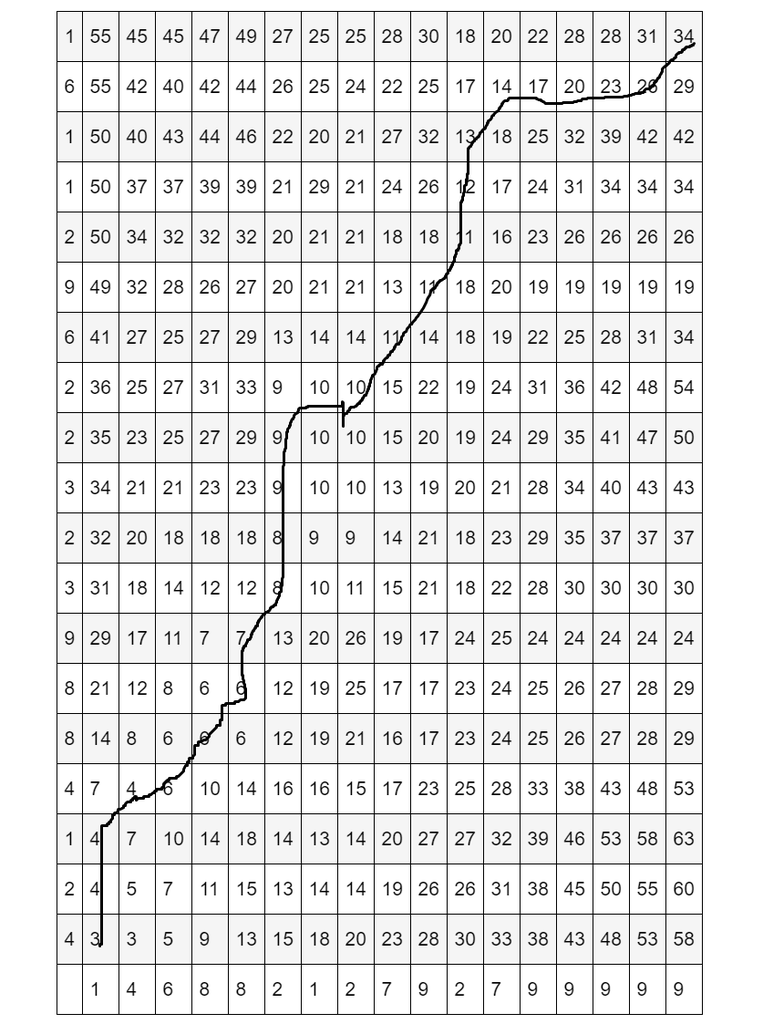

```python
display(HTML(
    '<style type="text/css">.tg {border-collapse:collapse;border-spacing:0;}.tg td{font-family:Arial, sans-serif;font-size:14px;padding:10px 5px;border-style:solid;border-width:1px;overflow:hidden;word-break:normal;border-color:black;}.tg th{font-family:Arial, sans-serif;font-size:14px;font-weight:normal;padding:10px 5px;border-style:solid;border-width:1px;overflow:hidden;word-break:normal;border-color:black;}.tg .tg-dvpl{border-color:inherit;text-align:right;vertical-align:top}.tg .tg-0pky{border-color:inherit;text-align:left;vertical-align:top}.tg .tg-0lax{text-align:left;vertical-align:top}</style><table class="tg"> <tr> <th class="tg-dvpl">1</th> <th class="tg-0pky">55</th> <th class="tg-0pky">45</th> <th class="tg-0pky">45</th> <th class="tg-0pky">47</th> <th class="tg-0pky">49</th> <th class="tg-0pky">27</th> <th class="tg-0pky">25</th> <th class="tg-0pky">25</th> <th class="tg-0pky">28</th> <th class="tg-0pky">30</th> <th class="tg-0pky">18</th> <th class="tg-0pky">20</th> <th class="tg-0pky">22</th> <th class="tg-0lax">28</th> <th class="tg-0lax">28</th> <th class="tg-0lax">31</th> <th class="tg-0lax">34</th> </tr> <tr> <td class="tg-0pky">6</td> <td class="tg-0pky">55</td> <td class="tg-0pky">42</td> <td class="tg-0pky">40</td> <td class="tg-0pky">42</td> <td class="tg-0pky">44</td> <td class="tg-0pky">26</td> <td class="tg-0pky">25</td> <td class="tg-0pky">24</td> <td class="tg-0pky">22</td> <td class="tg-0pky">25</td> <td class="tg-0pky">17</td> <td class="tg-0pky">14</td> <td class="tg-0pky">17</td> <td class="tg-0lax">20</td> <td class="tg-0lax">23</td> <td class="tg-0lax">26</td> <td class="tg-0lax">29</td> </tr> <tr> <td class="tg-0pky">1</td> <td class="tg-0pky">50</td> <td class="tg-0pky">40</td> <td class="tg-0pky">43</td> <td class="tg-0pky">44</td> <td class="tg-0pky">46</td> <td class="tg-0pky">22</td> <td class="tg-0pky">20</td> <td class="tg-0pky">21</td> <td class="tg-0pky">27</td> <td class="tg-0pky">32</td> <td class="tg-0pky">13</td> <td class="tg-0pky">18</td> <td class="tg-0pky">25</td> <td class="tg-0lax">32</td> <td class="tg-0lax">39</td> <td class="tg-0lax">42</td> <td class="tg-0lax">42</td> </tr> <tr> <td class="tg-0pky">1</td> <td class="tg-0pky">50</td> <td class="tg-0pky">37</td> <td class="tg-0pky">37</td> <td class="tg-0pky">39</td> <td class="tg-0pky">39</td> <td class="tg-0pky">21</td> <td class="tg-0pky">29</td> <td class="tg-0pky">21</td> <td class="tg-0pky">24</td> <td class="tg-0pky">26</td> <td class="tg-0pky">12</td> <td class="tg-0pky">17</td> <td class="tg-0pky">24</td> <td class="tg-0lax">31</td> <td class="tg-0lax">34</td> <td class="tg-0lax">34</td> <td class="tg-0lax">34</td> </tr> <tr> <td class="tg-0pky">2</td> <td class="tg-0pky">50</td> <td class="tg-0pky">34</td> <td class="tg-0pky">32</td> <td class="tg-0pky">32</td> <td class="tg-0pky">32</td> <td class="tg-0pky">20</td> <td class="tg-0pky">21</td> <td class="tg-0pky">21</td> <td class="tg-0pky">18</td> <td class="tg-0pky">18</td> <td class="tg-0pky">11</td> <td class="tg-0pky">16</td> <td class="tg-0pky">23</td> <td class="tg-0lax">26</td> <td class="tg-0lax">26</td> <td class="tg-0lax">26</td> <td class="tg-0lax">26</td> </tr> <tr> <td class="tg-0pky">9</td> <td class="tg-0pky">49</td> <td class="tg-0pky">32</td> <td class="tg-0pky">28</td> <td class="tg-0pky">26</td> <td class="tg-0pky">27</td> <td class="tg-0pky">20</td> <td class="tg-0pky">21</td> <td class="tg-0pky">21</td> <td class="tg-0pky">13</td> <td class="tg-0pky">11</td> <td class="tg-0pky">18</td> <td class="tg-0pky">20</td> <td class="tg-0pky">19</td> <td class="tg-0lax">19</td> <td class="tg-0lax">19</td> <td class="tg-0lax">19</td> <td class="tg-0lax">19</td> </tr> <tr> <td class="tg-0pky">6</td> <td class="tg-0pky">41</td> <td class="tg-0pky">27</td> <td class="tg-0pky">25</td> <td class="tg-0pky">27</td> <td class="tg-0pky">29</td> <td class="tg-0pky">13</td> <td class="tg-0pky">14</td> <td class="tg-0pky">14</td> <td class="tg-0pky">11</td> <td class="tg-0pky">14</td> <td class="tg-0pky">18</td> <td class="tg-0pky">19</td> <td class="tg-0pky">22</td> <td class="tg-0lax">25</td> <td class="tg-0lax">28</td> <td class="tg-0lax">31</td> <td class="tg-0lax">34</td> </tr> <tr> <td class="tg-0pky">2</td> <td class="tg-0pky">36</td> <td class="tg-0pky">25</td> <td class="tg-0pky">27</td> <td class="tg-0pky">31</td> <td class="tg-0pky">33</td> <td class="tg-0pky">9</td> <td class="tg-0pky">10</td> <td class="tg-0pky">10</td> <td class="tg-0pky">15</td> <td class="tg-0pky">22</td> <td class="tg-0pky">19</td> <td class="tg-0pky">24</td> <td class="tg-0pky">31</td> <td class="tg-0lax">36</td> <td class="tg-0lax">42</td> <td class="tg-0lax">48</td> <td class="tg-0lax">54</td> </tr> <tr> <td class="tg-0pky">2</td> <td class="tg-0pky">35</td> <td class="tg-0pky">23</td> <td class="tg-0pky">25</td> <td class="tg-0pky">27</td> <td class="tg-0pky">29</td> <td class="tg-0pky">9</td> <td class="tg-0pky">10</td> <td class="tg-0pky">10</td> <td class="tg-0pky">15</td> <td class="tg-0pky">20</td> <td class="tg-0pky">19</td> <td class="tg-0pky">24</td> <td class="tg-0pky">29</td> <td class="tg-0lax">35</td> <td class="tg-0lax">41</td> <td class="tg-0lax">47</td> <td class="tg-0lax">50</td> </tr> <tr> <td class="tg-0pky">3</td> <td class="tg-0pky">34</td> <td class="tg-0pky">21</td> <td class="tg-0pky">21</td> <td class="tg-0pky">23</td> <td class="tg-0pky">23</td> <td class="tg-0pky">9</td> <td class="tg-0pky">10</td> <td class="tg-0pky">10</td> <td class="tg-0pky">13</td> <td class="tg-0pky">19</td> <td class="tg-0pky">20</td> <td class="tg-0pky">21</td> <td class="tg-0pky">28</td> <td class="tg-0lax">34</td> <td class="tg-0lax">40</td> <td class="tg-0lax">43</td> <td class="tg-0lax">43</td> </tr> <tr> <td class="tg-0pky">2</td> <td class="tg-0pky">32</td> <td class="tg-0pky">20</td> <td class="tg-0pky">18</td> <td class="tg-0pky">18</td> <td class="tg-0pky">18</td> <td class="tg-0pky">8</td> <td class="tg-0pky">9</td> <td class="tg-0pky">9</td> <td class="tg-0pky">14</td> <td class="tg-0pky">21</td> <td class="tg-0pky">18</td> <td class="tg-0pky">23</td> <td class="tg-0pky">29</td> <td class="tg-0lax">35</td> <td class="tg-0lax">37</td> <td class="tg-0lax">37</td> <td class="tg-0lax">37</td> </tr> <tr> <td class="tg-0pky">3</td> <td class="tg-0pky">31</td> <td class="tg-0pky">18</td> <td class="tg-0pky">14</td> <td class="tg-0pky">12</td> <td class="tg-0pky">12</td> <td class="tg-0pky">8</td> <td class="tg-0pky">10</td> <td class="tg-0pky">11</td> <td class="tg-0pky">15</td> <td class="tg-0pky">21</td> <td class="tg-0pky">18</td> <td class="tg-0pky">22</td> <td class="tg-0pky">28</td> <td class="tg-0lax">30</td> <td class="tg-0lax">30</td> <td class="tg-0lax">30</td> <td class="tg-0lax">30</td> </tr> <tr> <td class="tg-0pky">9</td> <td class="tg-0pky">29</td> <td class="tg-0pky">17</td> <td class="tg-0pky">11</td> <td class="tg-0pky">7</td> <td class="tg-0pky">7</td> <td class="tg-0pky">13</td> <td class="tg-0pky">20</td> <td class="tg-0pky">26</td> <td class="tg-0pky">19</td> <td class="tg-0pky">17</td> <td class="tg-0pky">24</td> <td class="tg-0pky">25</td> <td class="tg-0pky">24</td> <td class="tg-0lax">24</td> <td class="tg-0lax">24</td> <td class="tg-0lax">24</td> <td class="tg-0lax">24</td> </tr> <tr> <td class="tg-0pky">8</td> <td class="tg-0pky">21</td> <td class="tg-0pky">12</td> <td class="tg-0pky">8</td> <td class="tg-0pky">6</td> <td class="tg-0pky">6</td> <td class="tg-0pky">12</td> <td class="tg-0pky">19</td> <td class="tg-0pky">25</td> <td class="tg-0pky">17</td> <td class="tg-0pky">17</td> <td class="tg-0pky">23</td> <td class="tg-0pky">24</td> <td class="tg-0pky">25</td> <td class="tg-0lax">26</td> <td class="tg-0lax">27</td> <td class="tg-0lax">28</td> <td class="tg-0lax">29</td> </tr> <tr> <td class="tg-0pky">8</td> <td class="tg-0pky">14</td> <td class="tg-0pky">8</td> <td class="tg-0pky">6</td> <td class="tg-0pky">6</td> <td class="tg-0pky">6</td> <td class="tg-0pky">12</td> <td class="tg-0pky">19</td> <td class="tg-0pky">21</td> <td class="tg-0pky">16</td> <td class="tg-0pky">17</td> <td class="tg-0pky">23</td> <td class="tg-0pky">24</td> <td class="tg-0pky">25</td> <td class="tg-0lax">26</td> <td class="tg-0lax">27</td> <td class="tg-0lax">28</td> <td class="tg-0lax">29</td> </tr> <tr> <td class="tg-0lax">4</td> <td class="tg-0lax">7</td> <td class="tg-0lax">4</td> <td class="tg-0lax">6</td> <td class="tg-0lax">10</td> <td class="tg-0lax">14</td> <td class="tg-0lax">16</td> <td class="tg-0lax">16</td> <td class="tg-0lax">15</td> <td class="tg-0lax">17</td> <td class="tg-0lax">23</td> <td class="tg-0lax">25</td> <td class="tg-0lax">28</td> <td class="tg-0lax">33</td> <td class="tg-0lax">38</td> <td class="tg-0lax">43</td> <td class="tg-0lax">48</td> <td class="tg-0lax">53</td> </tr> <tr> <td class="tg-0lax">1</td> <td class="tg-0lax">4</td> <td class="tg-0lax">7</td> <td class="tg-0lax">10</td> <td class="tg-0lax">14</td> <td class="tg-0lax">18</td> <td class="tg-0lax">14</td> <td class="tg-0lax">13</td> <td class="tg-0lax">14</td> <td class="tg-0lax">20</td> <td class="tg-0lax">27</td> <td class="tg-0lax">27</td> <td class="tg-0lax">32</td> <td class="tg-0lax">39</td> <td class="tg-0lax">46</td> <td class="tg-0lax">53</td> <td class="tg-0lax">58</td> <td class="tg-0lax">63</td> </tr> <tr> <td class="tg-0lax">2</td> <td class="tg-0lax">4</td> <td class="tg-0lax">5</td> <td class="tg-0lax">7</td> <td class="tg-0lax">11</td> <td class="tg-0lax">15</td> <td class="tg-0lax">13</td> <td class="tg-0lax">14</td> <td class="tg-0lax">14</td> <td class="tg-0lax">19</td> <td class="tg-0lax">26</td> <td class="tg-0lax">26</td> <td class="tg-0lax">31</td> <td class="tg-0lax">38</td> <td class="tg-0lax">45</td> <td class="tg-0lax">50</td> <td class="tg-0lax">55</td> <td class="tg-0lax">60</td> </tr> <tr> <td class="tg-0lax">4</td> <td class="tg-0lax">3</td> <td class="tg-0lax">3</td> <td class="tg-0lax">5</td> <td class="tg-0lax">9</td> <td class="tg-0lax">13</td> <td class="tg-0lax">15</td> <td class="tg-0lax">18</td> <td class="tg-0lax">20</td> <td class="tg-0lax">23</td> <td class="tg-0lax">28</td> <td class="tg-0lax">30</td> <td class="tg-0lax">33</td> <td class="tg-0lax">38</td> <td class="tg-0lax">43</td> <td class="tg-0lax">48</td> <td class="tg-0lax">53</td> <td class="tg-0lax">58</td> </tr> <tr> <td class="tg-0lax"></td> <td class="tg-0lax">1</td> <td class="tg-0lax">4</td> <td class="tg-0lax">6</td> <td class="tg-0lax">8</td> <td class="tg-0lax">8</td> <td class="tg-0lax">2</td> <td class="tg-0lax">1</td> <td class="tg-0lax">2</td> <td class="tg-0lax">7</td> <td class="tg-0lax">9</td> <td class="tg-0lax">2</td> <td class="tg-0lax">7</td> <td class="tg-0lax">9</td> <td class="tg-0lax">9</td> <td class="tg-0lax">9</td> <td class="tg-0lax">9</td> <td class="tg-0lax">9</td> </tr></table>'
) )
Image("ex1_3.png")
```

EX2: Extendible hashing is a dynamic hashing scheme. The difference between Dynamic and Static Hashing is that there is no need to recalculate new bucket address and touch items in all the other buckets in the hash table in Dynamic Hashing.

The dynamic hashing was invented to solve the problem of changing the size of the hash table. In static hashing, in order to change the hash table size, one must change the hashing function to one with a bigger table and re-hash all elements with the new function. I dynamic hashing, the table is split into buckets which hold multiple slots. When changing the size it is then only necessary to split the concerned buckets.

EX3: Extendable Hashing is designed to minimize the cost of rehashing. A Target bucket B will be split into B and B*. when B* is generated, B will be rehashed between B and B*. Hash function gives a hash value. Hash values is stored in hash table which is stored in main memory. Overflowing of buckets is not acceptable here. In Extendible Hashing, an auxiliary data structure is used which is called bucket directory. The principle is that pointers are used each entry to the buckets in hash table. Bucket directory is necessary structure here. When overflow happens, the B bucket is splitted to B and B* and bucket directory should be updated. Splitting is managed depending on global and local depth. Global Depth is equal to the number of bits used from the hash value generated by hash function. Local depth is calculated by buckets. While inserting if local depth is more than global depth, it is created new bucket to insert new value.

Example:

1. hash(4) = 100
2. hash(6) = 110
3. hash(1) = 01
4. hash(5) = 101

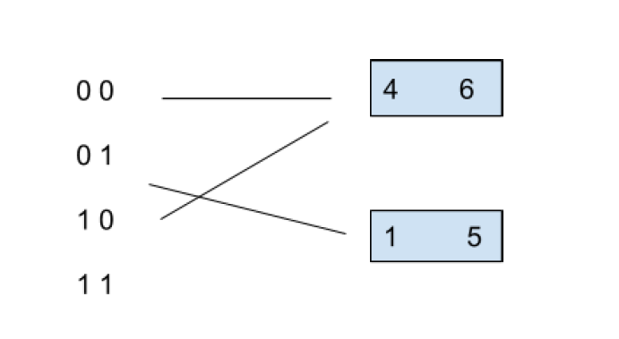

```python
from IPython.display import Image
Image("1.png")
```

In this case global depth is 2. Our hash function returns the binary format of the numbers. We save last 2 digits to create bucket directory. SO each pointer link connect hashs to buckets. If we want to insert 2 to the first bucket, we should split the bucket because it creates overflow.

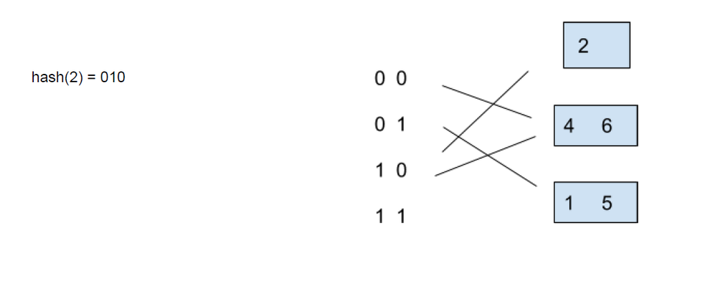

```python
from IPython.display import Image
Image("2.png")
```

EX4: In this exercice, I implemented two simple hashing algorithms. The first uses the sum of ord() of each letter, the second just the length of the word. As expected there are a lot of collisions (about half a million). In comparison, I used sha256 as good hashing algo, which yields almost no collisions. The most used integer and the plot are shown below.

```
most used int:  871
most used int:  10
most used int:  237234
```

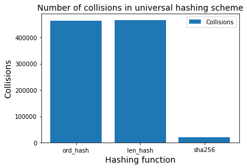

```python
from random import randint
import sympy
import matplotlib.pyplot as plt
import statistics
import hashlib
m=5000000
f = open('words.txt','r',encoding='utf-8')
data={}

p=sympy.nextprime(m)
def ord_hash(word):
    h=0
    for c in word:
        h+=ord(c)
    return h

def len_hash(word):
    return len(word)
def get_collision(t):
    collision=0
    for i in t:
        if i > 1:
            collision+=i-1
    return collision
table=[0 for i in range(0,m)]
for line in f:
    table[ord_hash(str(line))]+=1
print("most used int: ", table.index(max(table)))
data['ord_hash']=get_collision(table)
f.seek(0)

table=[0 for i in range(0,m)]
for line in f:
    table[len_hash(str(line))]+=1
print("most used int: ", table.index(max(table)))
data['len_hash']=get_collision(table)
f.seek(0)

table=[0 for i in range(0,m)]
for line in f:
    line = line.encode('utf-8')
    table[int(hashlib.sha256(line).hexdigest(), 16) % m]+=1
print("most used int: ", table.index(max(table)))
data['sha256']=get_collision(table)
f.seek(0)

plt.title("Number of collisions in universal hashing scheme", fontsize=14)
plt.ylabel('Collisions', fontsize=14)
plt.xlabel('Hashing function', fontsize=14)
plt.bar(list(range(len(data))), list(data.values()), align='center', label='Collisions')
plt.xticks(list(range(len(data))), list(data.keys()))
plt.legend()
plt.show()
```

EX5:I used Facebook, Twitter, Gnutella and Email datas.

Facebook:

The number of nodes: 2519, The number of edges: 333, Distribution of node degrees:

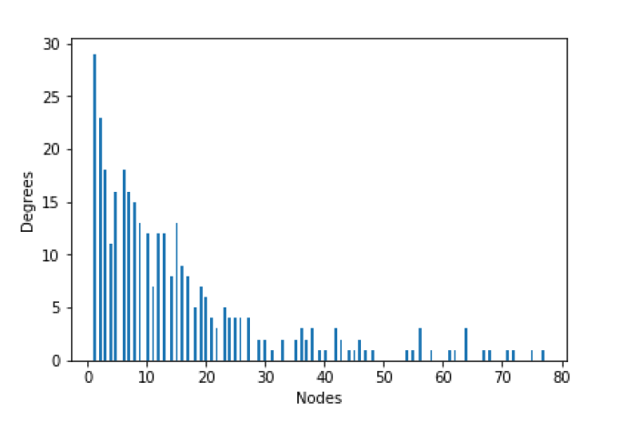

```python
from IPython.display import Image
Image("fb.png")
```

Twitter:

The number of nodes: 5971, The number of edges: 220, Distribution of node degrees:

Twitter is in-betweeen; not many connections in total, but the variance is high.

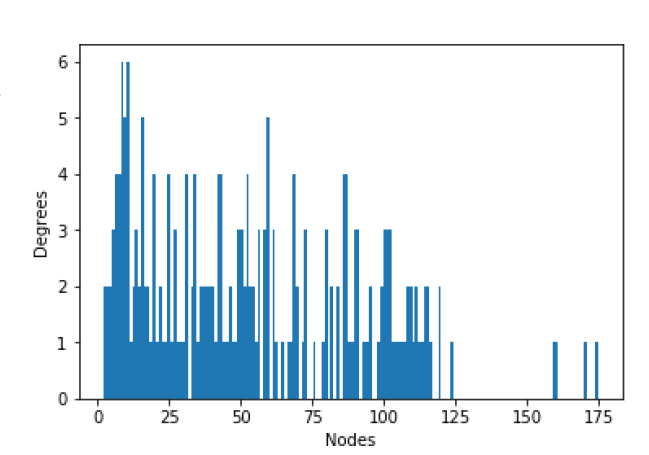

```python
Image("twitter.png")
```

Gnutella:

The number of nodes: 147892, The number of edges: 62586, Distribution of node degrees:

Gnutella is very centralized around one point and is very flat on the other points (decentralized)

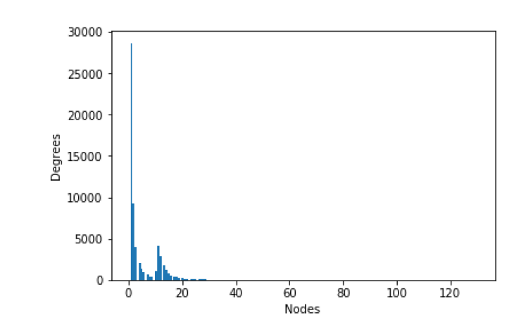

```python
Image("gnutella.png")
```

Email

The number of nodes: 183831, The number of edges: 36692, Distribution of node degrees:

Email is similar to gnutella.

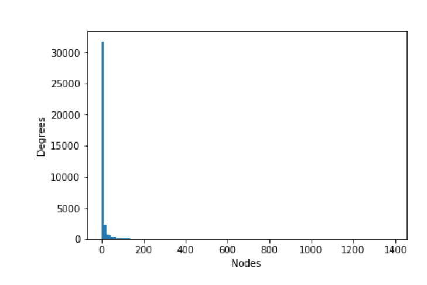

```python
Image("email.png")
```